# Polished Viz 5

Brett Chelf

2025-12-12

# Concept

For this last visualization, I want to create a network diagram using D3. In a different class of mine, I saw someone create a “pollinator web” showing the relationships between different flowering species and native pollinators. I think having an interactive version of this would be really powerful for educational purposes, so I wanted to focus on that task for this final. I haven’t done a lot of work with network data before, so it’s also a chance to tackle something I’m not experienced with and grow as a result. First I’ll need to set up my environment, then I’ll create or import my data, and then we can let D3 do most of the heavy lifting.

# Data

I’m going to build my own dataset based on information I could find from various official sources. It will be easier this way because there isn’t an existing dataset with the structure I need focused on Colorado species.

```
## EDGE LIST (relationships):
```

```
##    pollinator                    plant
## 1   Mason Bee Rocky Mountain Penstemon
## 2   Mason Bee    Firecracker Penstemon
## 3   Mason Bee  Rocky Mountain Beeplant
## 4   Mason Bee            Blanketflower
## 5   Mason Bee                Goldenrod
## 6   Mason Bee               Woods Rose
## 7   Mason Bee        Boulder Raspberry
## 8  Bumble Bee Rocky Mountain Penstemon
## 9  Bumble Bee       Colorado Columbine
## 10 Bumble Bee            Blanketflower
```

```
##
##
## NODE LIST (entities with attributes):
```

```
##                        name       type group
## 1                 Mason Bee pollinator     1
## 2                Bumble Bee pollinator     1
## 3         Monarch Butterfly pollinator     2
## 4     Swallowtail Butterfly pollinator     2
## 5               Hummingbird pollinator     3
## 6            Leafcutter Bee pollinator     1
## 7                Mining Bee pollinator     1
## 8               Syrphid Fly pollinator     4
## 9                 Hawk Moth pollinator     2
## 10 Rocky Mountain Penstemon      plant     6
## 11    Firecracker Penstemon      plant     6
## 12  Rocky Mountain Beeplant      plant     7
## 13            Blanketflower      plant     7
## 14                Goldenrod      plant     7
## 15               Woods Rose      plant     7
## 16        Boulder Raspberry      plant     7
## 17       Colorado Columbine      plant     7
## 18            Wild Bergamot      plant     7
## 19      Dotted Blazing Star      plant     7
## 20        Indian Paintbrush      plant     7
## 21           Showy Milkweed      plant     5
## 22       Butterfly Milkweed      plant     5
## 23            Scarlet Gilia      plant     7
```

```
##
##
## INDEXED EDGES (ready for networkD3):
```

[interactive chart not shown]

# First Network Diagram

This looks alright, but it’s not really what I had envisioned. I really want to show the interconnectedness of these species and this doesn’t show the complexity I’m trying to convey. I think the solution is to use a disjointed network instead, beacause I can use it to show “clusters” of relationships that may not be fully interconnected. I’ll also update my data to include more specialist relationships that I didn’t add before.

[interactive chart not shown]

# Finishing Touches

The bones are in plcea now, all I have to do is correct some of my data and category names. Then I can label the graph and edit some of the D3 parameters to get the aesthetics exactly how I want.

## Colorado Pollinator-Plant Relationships

[interactive chart not shown]

# Story Telling

This tool is really fun to navigate through, but it could be doing more to tell viewers about the vitality of these species and the threats posed to our ecosystems without them. I’ve decided to pair a suite of graphs along side this tool so that some more nuance can be communicated by this project.

## Colorado Pollinator-Plant Relationships

[interactive chart not shown]

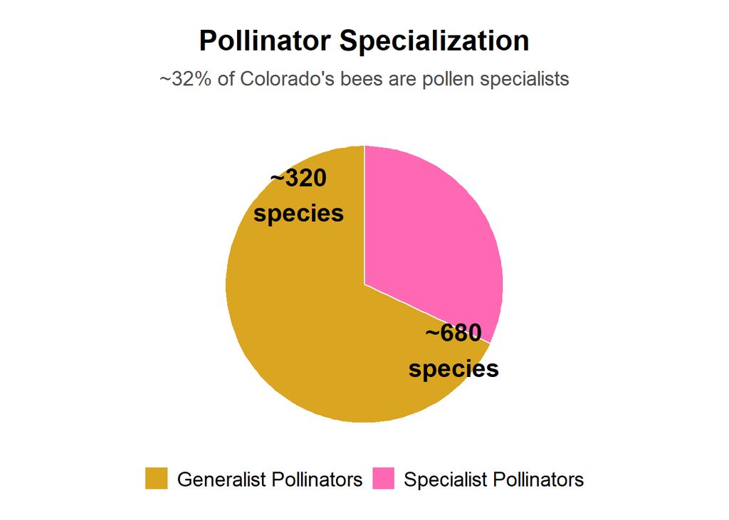

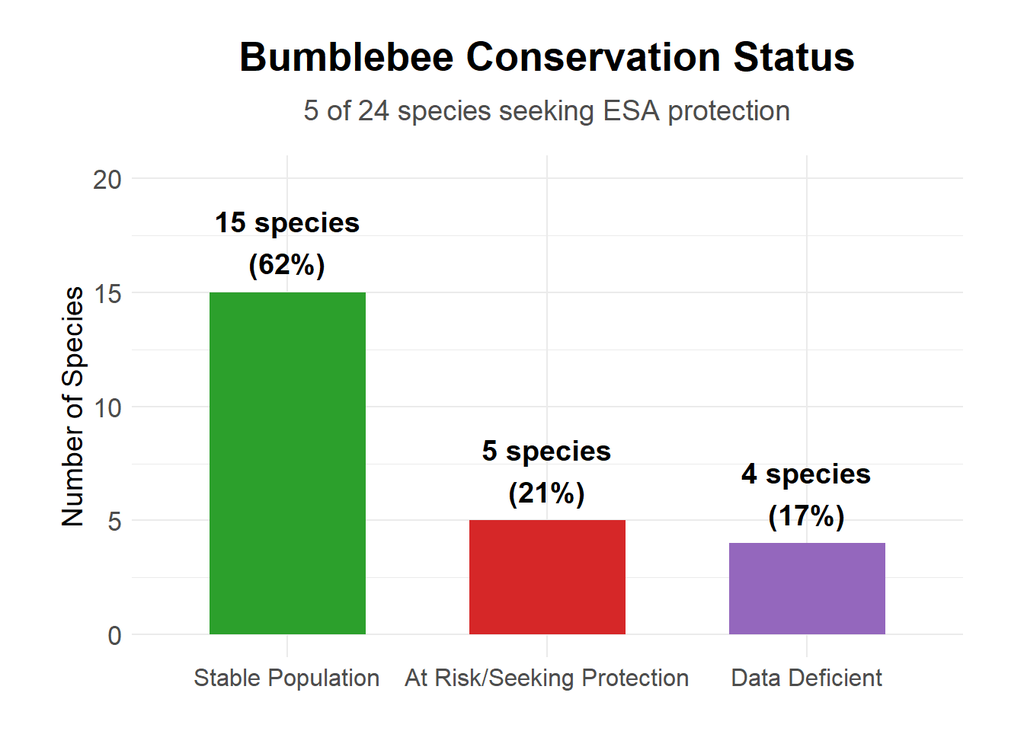

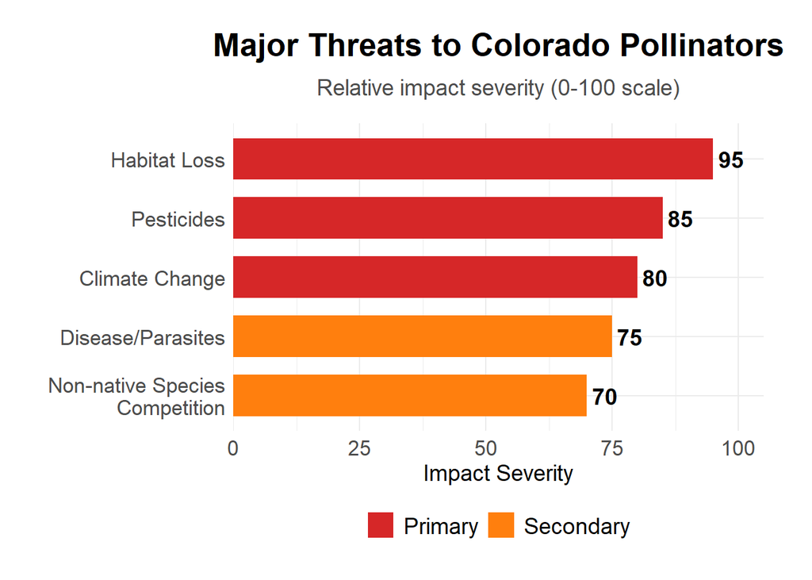

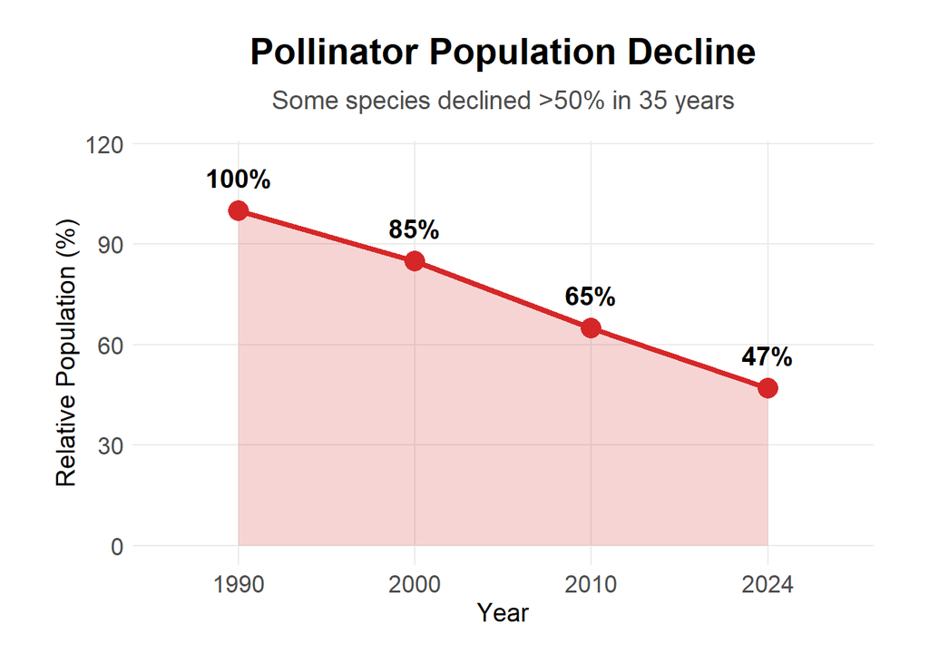

```
##
##  KEY CONSERVATION FINDINGS
```

```
## • Colorado hosts 1,000+ native bee species (30% of North America's bees)
```

```
## • ~32% of bee species are pollen specialists (vulnerable to habitat loss)
```

```
## • 20% of bumblebee species are seeking ESA protection
```

```
## • Some pollinator populations declined >50% in past 35 years
```

```
## • Primary threats: habitat loss, pesticides, climate change
```

```
## • Colorado ranks 5th nationally for honey bee die-offs
```

```
## • Non-native honey bees compete with native pollinators for resources
```

# Conclusion